# Customizing Wrapper Functions

Nickalus Redell

2020-05-05

## Purpose

The purpose of this vignette is to provide a closer look at how the user-supplied model training and predict wrapper functions can be modified to give greater control over the model-building process. The goal is to present examples of how the wrapper functions could be flexibly written to keep a linear workflow in `forecastML` while modeling across multiple forecast horizons and validation datasets. The alternative would be to train models across a single forecast horizon and/or validation window and customize the wrapper functions for this specific setup.

## Example 1 - Multiple forecast horizons and 1 model training function

- Load packages and data.

```r
library(DT)
library(dplyr)
library(ggplot2)
library(forecastML)
library(randomForest)

data("data_seatbelts", package = "forecastML")
data <- data_seatbelts

data <- data[, c("DriversKilled", "kms", "PetrolPrice", "law")]

dates <- seq(as.Date("1969-01-01"), as.Date("1984-12-01"), by = "1 month")
```

- Create a lagged data frame for model training. We’ll train 2 models: one across a 1:3-month horizon and the other across a 1:12-month horizon.

```r
data_train <- forecastML::create_lagged_df(data,
                                           type = "train",
                                           outcome_col = 1,
                                           lookback = 1:12,
                                           horizons = c(3, 12),
                                           dates = dates,
                                           frequency = "1 month")

# View the horizon 3 lagged dataset.
DT::datatable(head((data_train$horizon_3)), options = list("scrollX" = TRUE))
```

|  | DriversKilled | DriversKilled_lag_3 | DriversKilled_lag_4 | DriversKilled_lag_5 | DriversKilled_lag_6 | DriversKilled_lag_7 | DriversKilled_lag_8 | DriversKilled_lag_9 | DriversKilled_lag_10 | DriversKilled_lag_11 | DriversKilled_lag_12 | kms_lag_3 | kms_lag_4 | kms_lag_5 | kms_lag_6 | kms_lag_7 | kms_lag_8 | kms_lag_9 | kms_lag_10 | kms_lag_11 | kms_lag_12 | PetrolPrice_lag_3 | PetrolPrice_lag_4 | PetrolPrice_lag_5 | PetrolPrice_lag_6 | PetrolPrice_lag_7 | PetrolPrice_lag_8 | PetrolPrice_lag_9 | PetrolPrice_lag_10 | … |
| --- | --- | --- | --- | --- | --- | --- | --- | --- | --- | --- | --- | --- | --- | --- | --- | --- | --- | --- | --- | --- | --- | --- | --- | --- | --- | --- | --- | --- | --- | --- |
| 1 | 125 | 134 | 107 | 106 | 110 | 106 | 119 | 87 | 102 | 97 | 107 | 11372 | 12106 | 14055 | 13460 | 12391 | 11823 | 10955 | 9963 | 7685 | 9059 | 0.103026401330572 | 0.103773981457839 | 0.104076403554621 | 0.103773981457839 | 0.10058119170287 | 0.101019672891934 | 0.100873300511862 | 0.102062490635914 | … |
| 2 | 134 | 147 | 134 | 107 | 106 | 110 | 106 | 119 | 87 | 102 | 97 | 9834 | 11372 | 12106 | 14055 | 13460 | 12391 | 11823 | 10955 | 9963 | 7685 | 0.102730112155946 | 0.103026401330572 | 0.103773981457839 | 0.104076403554621 | 0.103773981457839 | 0.10058119170287 | 0.101019672891934 | 0.100873300511862 | … |
| 3 | 110 | 180 | 147 | 134 | 107 | 106 | 110 | 106 | 119 | 87 | 102 | 9267 | 9834 | 11372 | 12106 | 14055 | 13460 | 12391 | 11823 | 10955 | 9963 | 0.101997191539847 | 0.102730112155946 | 0.103026401330572 | 0.103773981457839 | 0.104076403554621 | 0.103773981457839 | 0.10058119170287 | 0.101019672891934 | … |
| 4 | 102 | 125 | 180 | 147 | 134 | 107 | 106 | 110 | 106 | 119 | 87 | 9130 | 9267 | 9834 | 11372 | 12106 | 14055 | 13460 | 12391 | 11823 | 10955 | 0.101274563494893 | 0.101997191539847 | 0.102730112155946 | 0.103026401330572 | 0.103773981457839 | 0.104076403554621 | 0.103773981457839 | 0.10058119170287 | … |
| 5 | 103 | 134 | 125 | 180 | 147 | 134 | 107 | 106 | 110 | 106 | 119 | 8933 | 9130 | 9267 | 9834 | 11372 | 12106 | 14055 | 13460 | 12391 | 11823 | 0.10070397563972 | 0.101274563494893 | 0.101997191539847 | 0.102730112155946 | 0.103026401330572 | 0.103773981457839 | 0.104076403554621 | 0.103773981457839 | … |
| 6 | 111 | 110 | 134 | 125 | 180 | 147 | 134 | 107 | 106 | 110 | 106 | 11000 | 8933 | 9130 | 9267 | 9834 | 11372 | 12106 | 14055 | 13460 | 12391 | 0.100139606658898 | 0.10070397563972 | 0.101274563494893 | 0.101997191539847 | 0.102730112155946 | 0.103026401330572 | 0.103773981457839 | 0.104076403554621 | … |

- We’ll train our models to predict on 1 validation dataset. Setting `window_length = 0` means that a single validation dataset will span from `window_start` to `window_stop`.

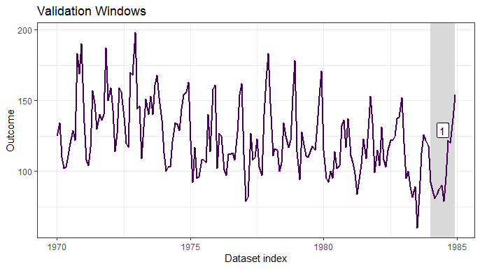

```r
windows <- forecastML::create_windows(data_train, window_length = 0,
                                      window_start = as.Date("1984-01-01"),
                                      window_stop = as.Date("1984-12-01"))

plot(windows, data_train)
```

### User-defined model-training function

- The key to customizing training across forecast horizons–here we have 2–is to modify the model training wrapper function based on the horizon-specific dataset in our `lagged_df` object `data_train`.
- Each dataset’s forecast horizon is stored as an attribute.

```r
attributes(data_train$horizon_3)$horizon
```

```
## [1] 3
```

```r
attributes(data_train$horizon_12)$horizon
```

```
## [1] 12
```

- We’ll train a Random Forest model with different settings for the 3-month and 12-month datasets.
- The first argument to the user-defined model training function is always the horizon-specific dataset from `create_lagged_df(type = "train")` and is passed into the wrapper function internally in `train_model()`. Any number of additional parameters can be defined in this wrapper function by either (a) setting arguments here–like below–or (b) setting the arguments in `train_model(...)`.

```r
model_function <- function(data, my_outcome_col = 1, n_tree = c(200, 100)) {

  outcome_names <- names(data)[my_outcome_col]
  model_formula <- formula(paste0(outcome_names,  "~ ."))

  if (attributes(data)$horizon == 3) {  # Model 1

          model <- randomForest::randomForest(formula = model_formula,
                                              data = data,
                                              ntree = n_tree[1])

          return(list("my_trained_model" = model, "n_tree" = n_tree[1],
                      "meta_data" = attributes(data)$horizon))

  } else if (attributes(data)$horizon == 12) {  # Model 2

          model <- randomForest::randomForest(formula = model_formula,
                                              data = data,
                                              ntree = n_tree[2])

          return(list("my_trained_model" = model, "n_tree" = n_tree[2],
                      "meta_data" = attributes(data)$horizon))
  }
}
```

- Train the models.

```r
model_results <- forecastML::train_model(data_train, windows, model_name = "RF", model_function)
```

- View the `return()` values from the user-defined `model_function()`. The returned values are stored in `my_training_results$horizon_h$window_w$model`.

```r
model_results$horizon_3$window_1$model
```

```
## $my_trained_model
##
## Call:
##  randomForest(formula = model_formula, data = data, ntree = n_tree[1])
##                Type of random forest: regression
##                      Number of trees: 200
## No. of variables tried at each split: 13
##
##           Mean of squared residuals: 247.162
##                     % Var explained: 59.72
##
## $n_tree
## [1] 200
##
## $meta_data
## [1] 3
```

```r
model_results$horizon_12$window_1$model
```

```
## $my_trained_model
##
## Call:
##  randomForest(formula = model_formula, data = data, ntree = n_tree[2])
##                Type of random forest: regression
##                      Number of trees: 100
## No. of variables tried at each split: 1
##
##           Mean of squared residuals: 420.6497
##                     % Var explained: 31.45
##
## $n_tree
## [1] 100
##
## $meta_data
## [1] 12
```

### User-defined prediction function

- The user-defined prediction function only takes two positional parameters. The first parameter is the returned value of the user-defined modeling function; here, a list with 3 elements. The second parameter is the horizon-specific dataset with model features from `create_lagged_df()` (`type = "train"` or `type = "forecast"`).

```r
prediction_function <- function(model, data_features) {

    if (model$meta_data == 3) {  # Perform a transformation specific to model 1.

        data_pred <- data.frame("y_pred" = predict(model$my_trained_model, data_features))
    }

    if (model$meta_data == 12) {  # Perform a transformation specific to model 2.

        data_pred <- data.frame("y_pred" = predict(model$my_trained_model, data_features))
    }

  return(data_pred)
}
```

- Predict

```r
data_results <- predict(model_results,
                        prediction_function = list(prediction_function),
                        data = data_train)
```

- Plot the performance on the validation dataset.

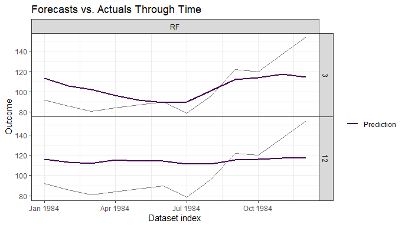

```r
plot(data_results)
```